# Introduction to R: Week 1 Solutions

visualising RNA-seq data with ggplot2

Maria Doyle

30 April 2019

#### Exercise

- Read in the normalised counts (from “/training/r-intro-tidyverse/data/normcounts.tsv.gz”)
- How many rows and columns are in the file
- In the first row, what is the sample id, the gene symbol and the value for the counts.
- In the last row, what is the sample id, the gene symbol and the value for the counts.
- Make as many plots as you can from bar plots, box plots, violin plots and density plots using the normalised counts (some starter code is below)
- Make separate plots coloured by Sample, CellType, Status, where appropriate.
- Do you notice any differences with the normalised counts versus the unnormalised counts that we used previously (`counts` dataset).

```r
norm_counts <- read_tsv("/training/r-intro-tidyverse/data/normcounts.tsv.gz")
```

```r
dim(norm_counts)
```

```
[1] 189648      5
```

There are 189,648 rows and 5 columns.

```r
head(norm_counts)
```

| Sample | CellType | Status | SYMBOL | Norm_counts |
| --- | --- | --- | --- | --- |
| DG | basal | virgin | Xkr4 | 3.932532 |
| DG | basal | virgin | Sox17 | 1.890808 |
| DG | basal | virgin | Mrpl15 | 3.429894 |
| DG | basal | virgin | Lypla1 | 4.505933 |
| DG | basal | virgin | Tcea1 | 5.804007 |
| DG | basal | virgin | Rgs20 | -2.673976 |

The column names are: Sample, CellType, Status, SYMBOL, Norm_counts.

In the first row, the sample is DG, the gene is Xkr4 and the counts value is 3.932532.

```r
tail(norm_counts)
```

| Sample | CellType | Status | SYMBOL | Norm_counts |
| --- | --- | --- | --- | --- |
| LF | luminal | lactate | G530011O06Rik | -3.1376521 |
| LF | luminal | lactate | NA | 2.2198999 |
| LF | luminal | lactate | NA | 6.3169899 |
| LF | luminal | lactate | NA | -0.1990527 |
| LF | luminal | lactate | NA | 0.9498107 |
| LF | luminal | lactate | Erdr1 | 3.0911666 |

In the last row, the sample is LF, the gene is Erdr1 and the counts value is 3.0911666.

```r
summary(norm_counts)
```

```
    Sample            CellType            Status             SYMBOL           Norm_counts
 Length:189648      Length:189648      Length:189648      Length:189648      Min.   :-5.889
 Class :character   Class :character   Class :character   Class :character   1st Qu.: 1.029
 Mode  :character   Mode  :character   Mode  :character   Mode  :character   Median : 3.660
                                                                             Mean   : 3.118
                                                                             3rd Qu.: 5.420
                                                                             Max.   :17.752
```

In the Norm_counts column, the minimum is -5.889, the maximum is 17.752, the mean is 3.118 and the median is 3.660.

## Bar plots

Bar plot coloured by Sample.

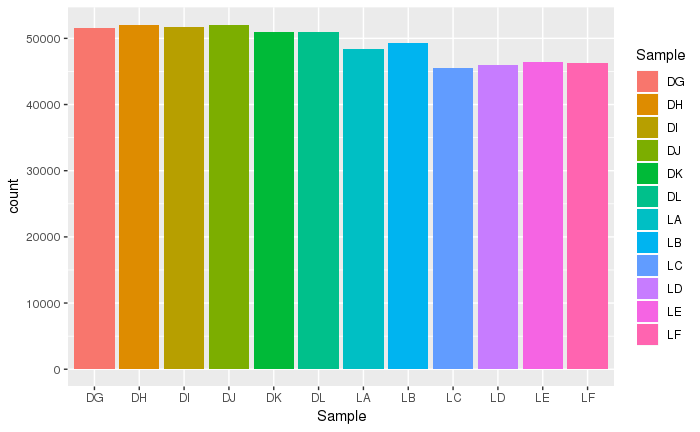

```r
ggplot(data=norm_counts, mapping=aes(x=Sample, weight=Norm_counts, fill=Sample)) +
  geom_bar()
```

Bar plot coloured by CellType.

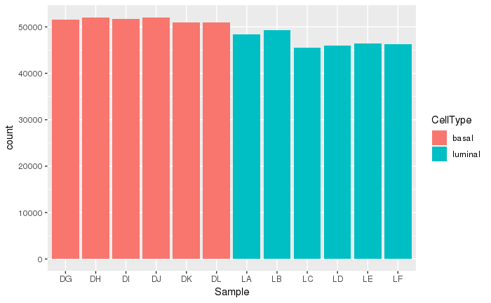

```r
ggplot(data=norm_counts, mapping=aes(x=Sample, weight=Norm_counts, fill=CellType)) +
  geom_bar()
```

Bar plot coloured by Status.

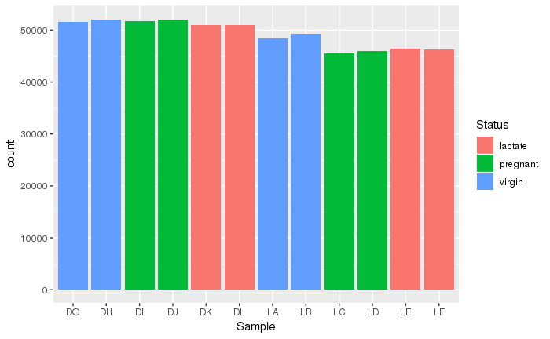

```r
ggplot(data=norm_counts, mapping=aes(x=Sample, weight=Norm_counts, fill=Status)) +
  geom_bar()
```

## Box plots

Box plots coloured by Sample.

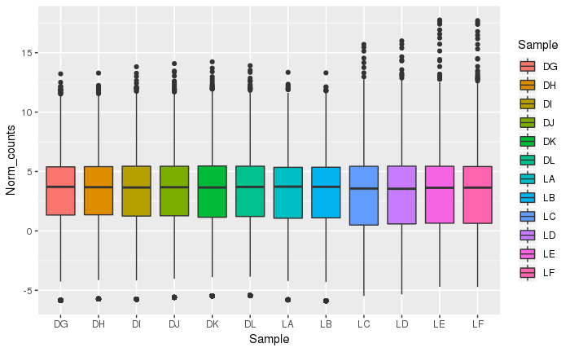

```r
ggplot(data=norm_counts, mapping=aes(x=Sample, y=Norm_counts, fill=Sample)) +
  geom_boxplot()
```

Box plots coloured by CellType.

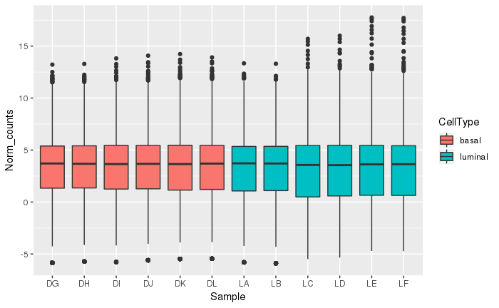

```r
ggplot(data=norm_counts, mapping=aes(x=Sample, y=Norm_counts, fill=CellType)) +
  geom_boxplot()
```

Box plots coloured by Status.

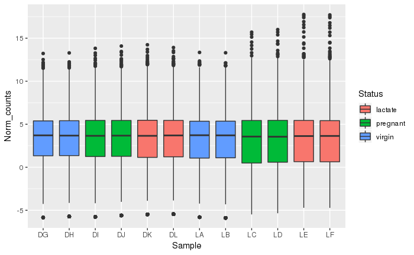

```r
ggplot(data=norm_counts, mapping=aes(x=Sample, y=Norm_counts, fill=Status)) +
  geom_boxplot()
```

## Violin plots

Violin plots coloured by Sample.

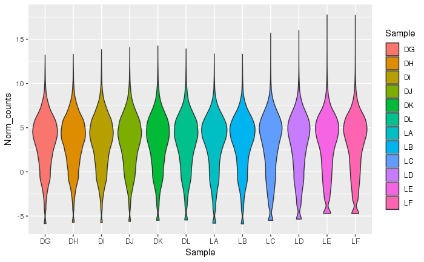

```r
ggplot(data=norm_counts, mapping=aes(x=Sample, y=Norm_counts, fill=Sample)) +
  geom_violin()
```

Violin plots coloured by CellType.

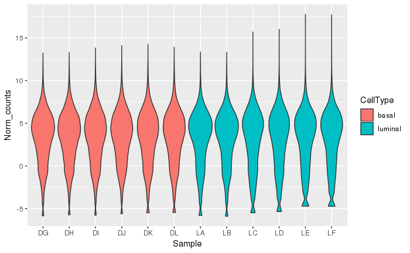

```r
ggplot(data=norm_counts, mapping=aes(x=Sample, y=Norm_counts, fill=CellType)) +
  geom_violin()
```

Violin plots coloured by Status.

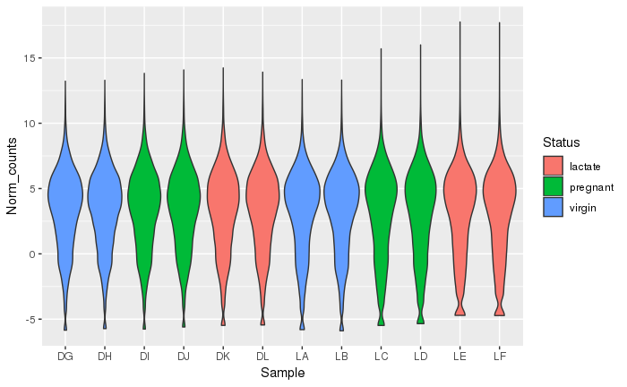

```r
ggplot(data=norm_counts, mapping=aes(x=Sample, y=Norm_counts, fill=Status)) +
  geom_violin()
```

## Density Plots

Density plots coloured by Sample.

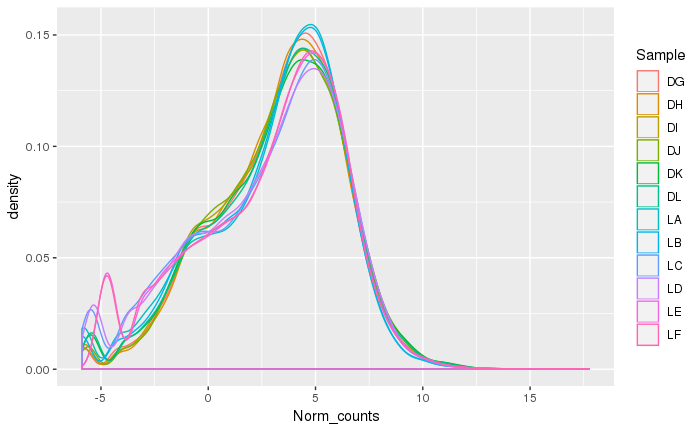

```r
ggplot(data=norm_counts, mapping=aes(x=Norm_counts, colour=Sample)) +
  geom_density()
```

Density plots coloured by CellType.

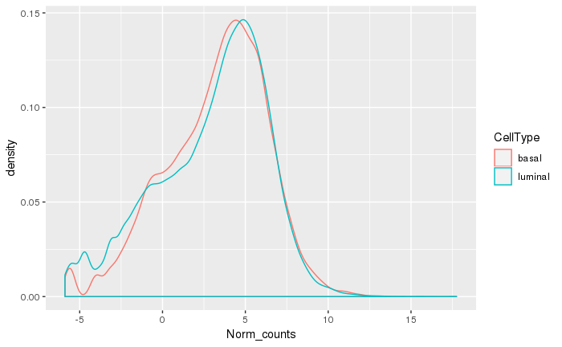

```r
ggplot(data=norm_counts, mapping=aes(x=Norm_counts, colour=CellType)) +
  geom_density()
```

Density plots coloured by Status.

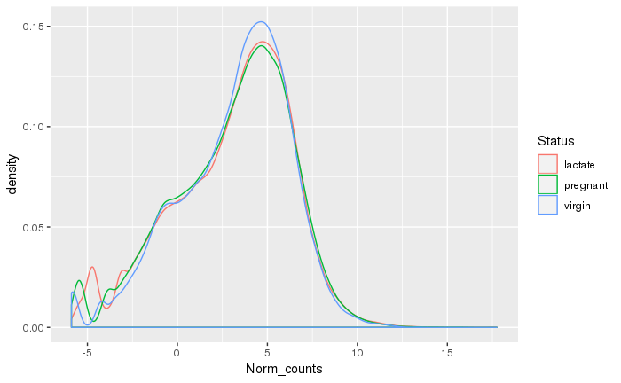

```r
ggplot(data=norm_counts, mapping=aes(x=Norm_counts, colour=Status)) +
  geom_density()
```

Differences versus the unnormalised counts * The normalised counts density plots don’t have the large peak on left that’s present in the unnormalised counts (the normalised counts have been filtered to remove lowly expressed genes) * The normalised counts box plots and violin plots, don’t give the warning about non-infinite values (the normalised counts have been filtered to remove lowly expressed genes) * In the box plots of normalised data, the median line is more similar in the samples compared to the unnormalised data.